# A very basic introduction to R

Political Science BA data course 2025-26

Author

Saar Alon-Barkat

Published

May 1, 2026

This file is a Quarto script file.

# 1. R is a smart calculator.

```r
1+1
```

```
[1] 2
```

```r
4*4
```

```
[1] 16
```

```r
0.5^2
```

```
[1] 0.25
```

```r
sqrt(0.25)
```

```
[1] 0.5
```

```r
log(2)
```

```
[1] 0.6931472
```

```r
rnorm(10)#rnorm represent a sample of n values from a normal distribution (by default mean=0 and SD=1).
```

```
 [1]  0.79174162 -1.25267686  1.67063237  1.25484891 -0.59673144 -0.65859962
 [7]  0.71462089  0.80901987  0.03492264 -1.68022236
```

# 2. R has “objects”.

You can create and name “objects” and they will be saved in your “environment”. To create an “object” use the sign “<-”

```r
my_first_object <- 1
```

From now on, when you type “my_first_object” R will read the value of it:

```r
my_first_object
```

```
[1] 1
```

Now try this:

```r
my_first_object + 2
```

```
[1] 3
```

You can also “override” objects:

```r
my_first_object <- my_first_object + 2

my_first_object
```

```
[1] 3
```

# 3. Vectors and data frames

Almost anything can be an object. For example, an object can be a single value, or a “vector” (series of values)

```r
my_first_vector <- c(1,2,3,4,5,6,7,8,9,10)

my_second_vector <- c("a","b","c","a","b","c","a","b","c","x")

my_third_vector <- c(TRUE,TRUE,FALSE,FALSE,TRUE,TRUE,TRUE,FALSE,FALSE,TRUE)
#Notice how c() is used to represent a series of values.

my_fourth_vector <- rnorm(10)

my_fifth_vector <- 0.5*my_fourth_vector + rnorm(10,mean=0,sd=0.5)



my_first_vector
```

```
 [1]  1  2  3  4  5  6  7  8  9 10
```

```r
my_second_vector
```

```
 [1] "a" "b" "c" "a" "b" "c" "a" "b" "c" "x"
```

```r
my_third_vector
```

```
 [1]  TRUE  TRUE FALSE FALSE  TRUE  TRUE  TRUE FALSE FALSE  TRUE
```

```r
my_fourth_vector
```

```
 [1]  1.33577946 -0.58184949 -1.19973227 -0.23630402  0.15770220 -0.84949953
 [7] -0.03089661  0.54027290  0.55287984  1.56842734
```

```r
my_fifth_vector
```

```
 [1]  0.53265500 -0.20308640 -0.37427902 -0.48498937  0.10530723 -0.64700135
 [7]  0.19684278  0.45478716 -0.06159483  0.76654044
```

Another important type of object is a data table, called “data frame”.

```r
my_first_dataframe <- data.frame(my_first_vector,
                                 my_second_vector,
                                 my_third_vector,
                                 my_fourth_vector,
                                 my_fifth_vector)
my_first_dataframe
```

```
   my_first_vector my_second_vector my_third_vector my_fourth_vector
1                1                a            TRUE       1.33577946
2                2                b            TRUE      -0.58184949
3                3                c           FALSE      -1.19973227
4                4                a           FALSE      -0.23630402
5                5                b            TRUE       0.15770220
6                6                c            TRUE      -0.84949953
7                7                a            TRUE      -0.03089661
8                8                b           FALSE       0.54027290
9                9                c           FALSE       0.55287984
10              10                x            TRUE       1.56842734
   my_fifth_vector
1       0.53265500
2      -0.20308640
3      -0.37427902
4      -0.48498937
5       0.10530723
6      -0.64700135
7       0.19684278
8       0.45478716
9      -0.06159483
10      0.76654044
```

In a data frame, each column is a “variable” and each row is an “observation”.

To extract a variable of a data frame you can use the $ sign:

```r
my_first_dataframe$my_first_vector
```

```
 [1]  1  2  3  4  5  6  7  8  9 10
```

Here is another way to do that:

```r
my_first_dataframe[,"my_first_vector"]
```

```
 [1]  1  2  3  4  5  6  7  8  9 10
```

And here is another way:

```r
my_first_dataframe[,1]
```

```
 [1]  1  2  3  4  5  6  7  8  9 10
```

The [,] structure enables you to extract an observation, and also a specific value of observation on a specific variable:

```r
my_first_dataframe[1,]
```

```
  my_first_vector my_second_vector my_third_vector my_fourth_vector
1               1                a            TRUE         1.335779
  my_fifth_vector
1        0.532655
```

```r
my_first_dataframe[1,1]
```

```
[1] 1
```

Now try these and see what happens:

```r
my_first_dataframe[1,1:2]
```

```
  my_first_vector my_second_vector
1               1                a
```

```r
my_first_dataframe[1:2,c(1,3)]
```

```
  my_first_vector my_third_vector
1               1            TRUE
2               2            TRUE
```

# 4. Data types

There are three main data types:

1. Numerics (numerics/integers/doubles). (Data represent numeric values)
2. Characters. (Such as text. Data does not represent numeric value)
3. Logicals (TRUE/FALSE)

Data frames typically consist of different types of variable.

One of the great things about R is that you can work with endless data frames (and other objects) at the same time (by comparison with other software).

```r
gapminder = read.csv("https://raw.githubusercontent.com/saaralonbarkat/BA-data-course/refs/heads/main/data/gapminder/gapminder_modern_1952_2022.csv")


head(gapminder)
```

```
      country year      pop continent lifeExp gdpPercap co2Percap
1 Afghanistan 1952  7987783      Asia    49.7  1846.705     0.012
2 Afghanistan 1957  8588335      Asia    51.4  2072.505     0.034
3 Afghanistan 1962  9404406      Asia    52.9  2293.423     0.074
4 Afghanistan 1967 10505959      Asia    54.1  2395.481     0.123
5 Afghanistan 1972 11853696      Asia    55.2  2011.685     0.130
6 Afghanistan 1977 13340756      Asia    55.9  2174.252     0.181
               regime
1 1. Closed autocracy
2 1. Closed autocracy
3 1. Closed autocracy
4 1. Closed autocracy
5 1. Closed autocracy
6 1. Closed autocracy
```

You will later learn how to import data files from your computer. Noteworthy that R can also import all data types (csv, xls, dta, sav…).

# 5. Basic operators

R has operators. We will get to know some of them.

‘==’ means “equal”

```r
1+2==2+1
```

```
[1] TRUE
```

```r
3+2==2+1
```

```
[1] FALSE
```

```r
my_first_dataframe$my_second_vector=="a"
```

```
 [1]  TRUE FALSE FALSE  TRUE FALSE FALSE  TRUE FALSE FALSE FALSE
```

‘!=’ means “not equal”

```r
3+2!=2+1
```

```
[1] TRUE
```

‘|’ means “or”

```r
my_first_dataframe[1,2]=="b"|my_first_dataframe[1,2]=="c"
```

```
[1] FALSE
```

```r
#You can also use the %in% operator:
my_first_dataframe[1,2] %in% c("b","c")
```

```
[1] FALSE
```

‘>’,‘<’,‘<=’,‘>=’ greater / smaller than signs

```r
my_first_dataframe$my_fourth_vector >= 0
```

```
 [1]  TRUE FALSE FALSE FALSE  TRUE FALSE FALSE  TRUE  TRUE  TRUE
```

Let’s use the `==` operator to filter the data (next meeting we will learn other ways to do it):

```r
gapminder_2007 <- gapminder[gapminder$year==2007,]
```

# 5. Functions and packages

R has multiple built-in functions. Here are some examples:

```r
round(1.168)
```

```
[1] 1
```

```r
mean(gapminder_2007$lifeExp) # Mean of a variable
```

```
[1] 69.97216
```

```r
table(gapminder_2007$continent) # Frequency table
```

```
  Africa Americas     Asia   Europe  Oceania
      54       35       48       43       14
```

```r
summary(gapminder_2007)
```

```
   country               year           pop             continent
 Length:194         Min.   :2007   Min.   :1.002e+04   Length:194
 Class :character   1st Qu.:2007   1st Qu.:1.609e+06   Class :character
 Mode  :character   Median :2007   Median :7.079e+06   Mode  :character
                    Mean   :2007   Mean   :3.462e+07
                    3rd Qu.:2007   3rd Qu.:2.210e+07
                    Max.   :2007   Max.   :1.326e+09

    lifeExp        gdpPercap          co2Percap          regime
 Min.   :43.50   Min.   :   680.8   Min.   : 0.0240   Length:194
 1st Qu.:64.22   1st Qu.:  4071.1   1st Qu.: 0.6162   Class :character
 Median :72.65   Median : 11199.6   Median : 2.4590   Mode  :character
 Mean   :69.97   Mean   : 22489.9   Mean   : 5.0819
 3rd Qu.:75.75   3rd Qu.: 29260.1   3rd Qu.: 8.1185
 Max.   :83.10   Max.   :335747.8   Max.   :31.9960
                 NA's   :1          NA's   :2
```

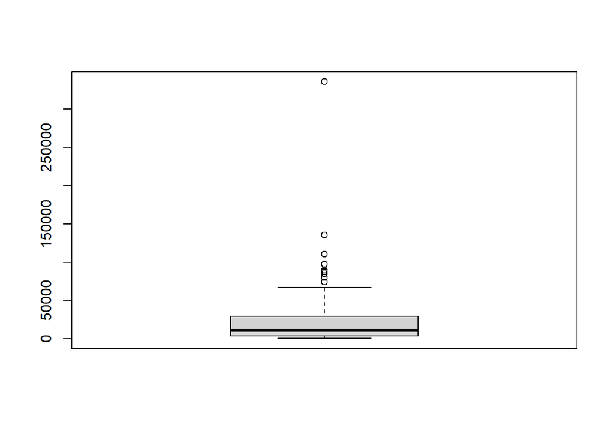

```r
boxplot(gapminder_2007$gdpPercap)
```

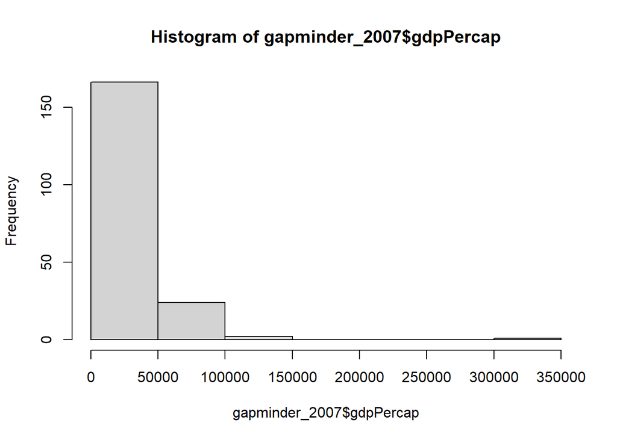

```r
hist(gapminder_2007$gdpPercap)
```

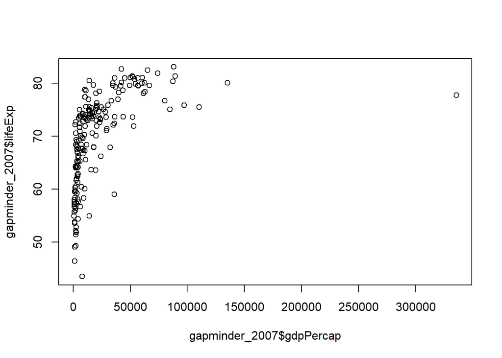

```r
plot(gapminder_2007$gdpPercap,gapminder_2007$lifeExp)
```

```r
cor.test(gapminder_2007$gdpPercap,gapminder_2007$lifeExp) # Correlation coefficient test
```

```
    Pearson's product-moment correlation

data:  gapminder_2007$gdpPercap and gapminder_2007$lifeExp
t = 7.7957, df = 191, p-value = 4.027e-13
alternative hypothesis: true correlation is not equal to 0
95 percent confidence interval:
 0.3761670 0.5914991
sample estimates:
      cor
0.4913042
```

```r
model1 <- lm(lifeExp~gdpPercap,data=gapminder_2007) # Linear OLS regression model
summary(model1)
```

```
Call:
lm(formula = lifeExp ~ gdpPercap, data = gapminder_2007)

Residuals:
    Min      1Q  Median      3Q     Max
-32.314  -3.950   2.026   5.396  11.679

Coefficients:
             Estimate Std. Error t value Pr(>|t|)
(Intercept) 6.703e+01  6.535e-01 102.558  < 2e-16 ***
gdpPercap   1.283e-04  1.646e-05   7.796 4.03e-13 ***
---
Signif. codes:  0 '***' 0.001 '**' 0.01 '*' 0.05 '.' 0.1 ' ' 1

Residual standard error: 7.482 on 191 degrees of freedom
  (1 observation deleted due to missingness)
Multiple R-squared:  0.2414,    Adjusted R-squared:  0.2374
F-statistic: 60.77 on 1 and 191 DF,  p-value: 4.027e-13
```

```r
# Notice that `summary` and `plot` are versatile functions. They do different things depending on the type of data.
```

These ready to use functions are called “base R” functions.

R also let’s you create your own functions. e.g. - this very basic function will extract the sum of two numbers

```r
myfunction <- function(x,y){
  z = x+y
  print(z)
  }

myfunction(2,4)
```

```
[1] 6
```

But, one of the things that are great in R is that there are endless extensions that you can download (like apps in your smartphone). These extensions are called “packages” or “libraries”.

# 6. Tidyverse

We will work with the very useful set of packages in “tidyverse”. In the first time you are using a package you need to download and install it with `install.packages`

```r
#install.packages("tidyverse")
```

Then, you need to open it - and it is ready.

```r
library(tidyverse)
```

Tidyverse is a set of packages that provide solutions to all of the stages in the data workflow (import, tidy, transform, visualize, model, communicate).

It uses a unified simple, intuitive human language where functions are verbs.

For example, instead of `gapminder_2007 <- gapminder[gapminder$year==2007,]` - you can write:

```r
gapminder %>%
  filter(year==2007)
```

```
                           country year        pop continent lifeExp
1                      Afghanistan 2007   25909852      Asia    64.3
2                          Albania 2007    3022887    Europe    77.4
3                          Algeria 2007   34189416    Africa    74.1
4                          Andorra 2007      81877    Europe    82.5
5                           Angola 2007   20778561    Africa    58.3
6              Antigua and Barbuda 2007      81704  Americas    76.7
7                        Argentina 2007   40016763  Americas    75.1
8                          Armenia 2007    2974819      Asia    73.3
9                        Australia 2007   20954549   Oceania    81.4
10                         Austria 2007    8296952    Europe    80.0
11                      Azerbaijan 2007    8828311      Asia    70.6
12                         Bahamas 2007     353334  Americas    72.4
13                         Bahrain 2007    1057405      Asia    73.6
14                      Bangladesh 2007  147989278      Asia    67.0
```

[output cut: 375 more lines]

```r
gapminder %>%
  filter(year==2007)%>%
  head()
```

```
              country year      pop continent lifeExp gdpPercap co2Percap
1         Afghanistan 2007 25909852      Asia    64.3  2132.605     0.084
2             Albania 2007  3022887    Europe    77.4 10272.645     2.000
3             Algeria 2007 34189416    Africa    74.1 14137.481     3.175
4             Andorra 2007    81877    Europe    82.5 65192.704     6.520
5              Angola 2007 20778561    Africa    58.3  9191.411     1.196
6 Antigua and Barbuda 2007    81704  Americas    76.7 33336.860     5.586
                  regime
1 2. Electoral autocracy
2 3. Electoral democracy
3 2. Electoral autocracy
4                   <NA>
5    1. Closed autocracy
6                   <NA>
```

```r
gapminder_2007 %>%
  arrange(lifeExp)%>%
  head()
```

```
                   country year      pop continent lifeExp gdpPercap co2Percap
1                 Eswatini 2007  1090705    Africa    43.5  7904.882     1.034
2                   Rwanda 2007  9549933    Africa    46.4  1524.636     0.058
3 Central African Republic 2007  4462770    Africa    49.1  1280.714     0.060
4                  Lesotho 2007  1953268    Africa    49.3  2484.136     1.045
5                 Zimbabwe 2007 12804058    Africa    51.4  2372.237     0.903
6                   Zambia 2007 12565085    Africa    51.8  2808.614     0.476
                  regime
1    1. Closed autocracy
2 2. Electoral autocracy
3 2. Electoral autocracy
4 3. Electoral democracy
5 2. Electoral autocracy
6 3. Electoral democracy
```

The `%\>%` operator is called “pipe”. It is an important element in Tidyverse and it is extremely useful. It makes tidyverse code very elegant - intuitive and easy to read, understand and learn. Last year, R also implemented a “base pipe” that can also work: `|>`. So you can either use `%>%` or `|>`

```r
gapminder %>%
  filter(year==2007) %>%
  select(continent,country,lifeExp) %>%
  arrange(lifeExp)
```

```
    continent                        country lifeExp
1      Africa                       Eswatini    43.5
2      Africa                         Rwanda    46.4
3      Africa       Central African Republic    49.1
4      Africa                        Lesotho    49.3
5      Africa                       Zimbabwe    51.4
6      Africa                         Zambia    51.8
7      Africa                   Sierra Leone    52.1
8      Africa                           Chad    52.8
9      Africa                         Malawi    53.6
10     Africa                          Niger    53.8
11     Africa                       Cameroon    54.4
12     Africa                   South Africa    54.9
13     Africa                    South Sudan    54.9
14     Africa               Congo, Dem. Rep.    55.7
```

[output cut: 180 more lines]

We will often use tidyverse in the course. We recommend you to get used to working with it (but you prefer to use base R that’s also ok). In the end you will develop your own habits and coding style.